# Running the FishKelp model for the Blamey and Bolton fish

- Show All Code
- Hide All Code
- View Source

Instructions and results for Zoë

Author

AJ Smit

Published

August 19, 2026

# Zoë, start here

I have prepared the FishKelp data for every fish listed in Table 2 of Blamey and Bolton (2018). This file shows you what is available, how the model uses it, and how to repeat the full analysis on your computer.

The paper lists 30 fish associated with South African kelp forest and temperate reef ecosystems. That wording needs care. The table combines two habitats, and its columns describe fisheries and exploitation status. I have used the table to define the fish set, but not as evidence that each fish uses kelp. The FishKelp literature assessment supplies that evidence.

Please keep the trophic and habitat routes separate. A fish may feed on kelp or kelp-associated prey without using kelp structure as habitat. It may also occur within a kelp forest without evidence of either action. The model retains those distinctions.

# What I have packaged for you

The `data/fishkelp_v7` directory contains the published species list, the FishKelp evidence records for those species, their traits, and the posterior summaries from the production model. I have included the full model-ready R object as well. You do not need access to my FishKelp directory to run this analysis.

Five of the 30 fish do not have a posterior estimate in FishKelp v7. *Chrysoblephus anglicus* falls outside the review boundary. *Coryphaena hippurus* and *Polysteganus praeorbitalis* do not occur in the v7 review species frame. *Seriola lalandi* and *Thyrsites atun* are in scope, but no model-ready records occur for them in this snapshot.

Do not replace those missing estimates with zero. Missing means that the model did not estimate the species. A zero would state that the evidence supports no kelp relationship, which is a different claim.

```r
qmd_path <- normalizePath(knitr::current_input(dir = TRUE), mustWork = TRUE)
repo_root <- dirname(dirname(qmd_path))
bundle_dir <- file.path(repo_root, "data", "fishkelp_v7")

fish <- read.csv(
  file.path(bundle_dir, "blamey_bolton_2018_fish.csv"),
  stringsAsFactors = FALSE,
  check.names = FALSE
)
packaged_estimates <- read.csv(
  file.path(bundle_dir, "fishkelp_posterior_estimates_v7.csv"),
  stringsAsFactors = FALSE,
  check.names = FALSE,
  na.strings = c("NA", "")
)
estimates <- packaged_estimates[packaged_estimates$modelled_v7,]
estimates$species <- estimates$accepted_name
estimates <- estimates[order(-estimates$T_reach),]
```

# Check the species coverage

The status table below records all 30 fish. The record counts refer to evidence from the full FishKelp literature assessment, not only to Blamey and Bolton (2018).

```r
coverage <- fish[, c(
  "table_order",
  "common_name_published",
  "scientific_name_published",
  "accepted_name",
  "model_status_v7",
  "n_model_records_v7",
  "n_analysis_records_v7"
)]
names(coverage) <- c(
  "Order",
  "Common name",
  "Published name",
  "FishKelp name",
  "Model status",
  "Model records",
  "Analysis records"
)
knitr::kable(coverage, caption = "Coverage of the 30 fish in Table 2.")
```

Coverage of the 30 fish in Table 2.

| Order | Common name | Published name | FishKelp name | Model status | Model records | Analysis records |
| --- | --- | --- | --- | --- | --- | --- |
| 1 | Baardman | Umbrina sp. | Umbrina robinsoni | modelled | 27 | 27 |
| 2 | Black musselcracker | Cymatoceps nasutus | Cymatoceps nasutus | modelled | 46 | 46 |
| 3 | Blacktail | Diplodus sargus capensis | Diplodus capensis | modelled | 145 | 145 |
| 4 | Bronze bream | Pachymetopon grande | Pachymetopon grande | modelled | 42 | 42 |
| 5 | Cape knifejaw | Oplegnathus conwayi | Oplegnathus conwayi | modelled | 20 | 20 |
| 6 | Cape stumpnose | Rhabdosargus holubi | Rhabdosargus holubi | modelled | 129 | 129 |
| 7 | Carpenter | Argyrozona argyrozona | Argyrozona argyrozona | modelled | 53 | 54 |
| 8 | Common smooth-hound shark | Mustelus mustelus | Mustelus mustelus | modelled | 64 | 64 |
| 9 | Dageraad | Chrysoblephus cristiceps | Chrysoblephus cristiceps | modelled | 36 | 36 |
| 10 | Dorado | Coryphaena hippurus | Coryphaena hippurus | not_in_rfbf_species_frame | 0 | 0 |
| 11 | Elf | Pomatomus saltatrix | Pomatomus saltatrix | modelled | 118 | 118 |
| 12 | Englishman | Chrysoblephus anglicus | Chrysoblephus anglicus | outside_rfbf_scope | 0 | 15 |
| 13 | Garrick | Lichia amia | Lichia amia | modelled | 79 | 79 |
| 14 | Geelbek | Atractoscion aequidens | Atractoscion aequidens | modelled | 66 | 66 |
| 15 | Hottentot | Pachymetopon blochii | Pachymetopon blochii | modelled | 46 | 46 |
| 16 | Janbruin | Gymnocrotaphus curvidens | Gymnocrotaphus curvidens | modelled | 35 | 35 |
| 17 | Panga | Pterogymnus laniarius | Pterogymnus laniarius | modelled | 43 | 43 |
| 18 | Roman | Chrysoblephus laticeps | Chrysoblephus laticeps | modelled | 70 | 70 |
| 19 | Red steenbras | Petrus rupestris | Petrus rupestris | modelled | 51 | 52 |
| 20 | Red stumpnose | Chrysoblephus gibbiceps | Chrysoblephus gibbiceps | modelled | 43 | 43 |
| 21 | Santer | Cheimerius nufar | Cheimerius nufar | modelled | 70 | 70 |
| 22 | Scotsman | Polysteganus praeorbitalis | Polysteganus praeorbitalis | not_in_rfbf_species_frame | 0 | 0 |
| 23 | Snoek | Thyrsites atun | Thyrsites atun | no_model_ready_records | 0 | 0 |
| 24 | Soupfin shark | Galeorhinus galeus | Galeorhinus galeus | modelled | 39 | 40 |
| 25 | Pyjama shark | Poroderma africanum | Poroderma africanum | modelled | 80 | 80 |
| 26 | White musselcracker | Sparodon durbanensis | Sparodon durbanensis | modelled | 53 | 53 |
| 27 | White stumpnose | Rhabdosargus globiceps | Rhabdosargus globiceps | modelled | 91 | 92 |
| 28 | Yellow-belly rockcod | Epinephelus marginatus | Epinephelus marginatus | modelled | 58 | 58 |
| 29 | Yellowtail | Seriola lalandi | Seriola lalandi | no_model_ready_records | 0 | 0 |
| 30 | Zebra fish | Diplodus cervinus hottentotus | Diplodus hottentotus | modelled | 94 | 94 |

# Current model result

This report uses the production summaries packaged from FishKelp v7. The model estimates 25 of the paper’s fish.

```r
posterior_table <- estimates[, c(
  "species",
  "T_reach",
  "T_reach_lo",
  "T_reach_hi",
  "H_reach",
  "H_reach_lo",
  "H_reach_hi"
)]
names(posterior_table) <- c(
  "Species",
  "T mean",
  "T 2.5%",
  "T 97.5%",
  "H mean",
  "H 2.5%",
  "H 97.5%"
)
knitr::kable(
  posterior_table,
  digits = 3,
  caption = "Posterior expected evidentiary reach for the 25 modelled fish."
)
```

Posterior expected evidentiary reach for the 25 modelled fish.

|  | Species | T mean | T 2.5% | T 97.5% | H mean | H 2.5% | H 97.5% |
| --- | --- | --- | --- | --- | --- | --- | --- |
| 15 | Pachymetopon blochii | 0.468 | 0.068 | 1.133 | 0.409 | 0.191 | 0.654 |
| 4 | Pachymetopon grande | 0.053 | 0.000 | 0.398 | 0.307 | 0.031 | 0.723 |
| 5 | Oplegnathus conwayi | 0.043 | 0.000 | 0.320 | 0.234 | 0.021 | 0.632 |
| 3 | Diplodus capensis | 0.038 | 0.000 | 0.249 | 0.279 | 0.089 | 0.526 |
| 6 | Rhabdosargus holubi | 0.036 | 0.000 | 0.286 | 0.027 | 0.000 | 0.149 |
| 17 | Pterogymnus laniarius | 0.035 | 0.000 | 0.289 | 0.155 | 0.015 | 0.436 |
| 21 | Cheimerius nufar | 0.032 | 0.000 | 0.268 | 0.026 | 0.000 | 0.164 |
| 26 | Sparodon durbanensis | 0.025 | 0.000 | 0.225 | 0.115 | 0.001 | 0.454 |
| 28 | Epinephelus marginatus | 0.025 | 0.000 | 0.220 | 0.180 | 0.006 | 0.550 |
| 13 | Lichia amia | 0.024 | 0.000 | 0.234 | 0.005 | 0.000 | 0.040 |
| 25 | Poroderma africanum | 0.024 | 0.000 | 0.182 | 0.437 | 0.222 | 0.668 |
| 8 | Mustelus mustelus | 0.020 | 0.000 | 0.157 | 0.105 | 0.015 | 0.275 |
| 20 | Chrysoblephus gibbiceps | 0.020 | 0.000 | 0.160 | 0.124 | 0.013 | 0.355 |
| 27 | Rhabdosargus globiceps | 0.020 | 0.000 | 0.180 | 0.006 | 0.000 | 0.038 |
| 11 | Pomatomus saltatrix | 0.019 | 0.000 | 0.172 | 0.008 | 0.000 | 0.052 |
| 14 | Atractoscion aequidens | 0.018 | 0.000 | 0.162 | 0.004 | 0.000 | 0.031 |
| 16 | Gymnocrotaphus curvidens | 0.018 | 0.000 | 0.149 | 0.270 | 0.048 | 0.616 |
| 1 | Umbrina robinsoni | 0.017 | 0.000 | 0.152 | 0.042 | 0.000 | 0.224 |
| 30 | Diplodus hottentotus | 0.017 | 0.000 | 0.137 | 0.142 | 0.015 | 0.389 |
| 2 | Cymatoceps nasutus | 0.016 | 0.000 | 0.137 | 0.283 | 0.039 | 0.659 |
| 7 | Argyrozona argyrozona | 0.016 | 0.000 | 0.161 | 0.110 | 0.007 | 0.348 |
| 9 | Chrysoblephus cristiceps | 0.015 | 0.000 | 0.127 | 0.295 | 0.039 | 0.691 |
| 18 | Chrysoblephus laticeps | 0.014 | 0.000 | 0.115 | 0.323 | 0.112 | 0.586 |
| 24 | Galeorhinus galeus | 0.014 | 0.000 | 0.153 | 0.001 | 0.000 | 0.014 |
| 19 | Petrus rupestris | 0.013 | 0.000 | 0.131 | 0.077 | 0.001 | 0.326 |

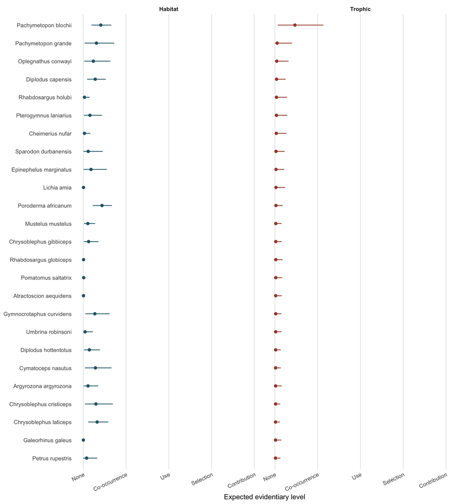

Trophic and habitat evidentiary reach for the 25 modelled fish. Points show posterior means and lines show 95% credible intervals.

```r
plot_data <- rbind(
  data.frame(
    species = estimates$species,
    Route = "Trophic",
    Mean = estimates$T_reach,
    Lower = estimates$T_reach_lo,
    Upper = estimates$T_reach_hi
  ),
  data.frame(
    species = estimates$species,
    Route = "Habitat",
    Mean = estimates$H_reach,
    Lower = estimates$H_reach_lo,
    Upper = estimates$H_reach_hi
  )
)
plot_data$species <- factor(
  plot_data$species,
  levels = rev(estimates$species)
)

ggplot2::ggplot(
  plot_data,
  ggplot2::aes(x = Mean, y = species, colour = Route)
) +
  ggplot2::geom_vline(
    xintercept = 0:4,
    colour = "grey90",
    linewidth = 0.35
  ) +
  ggplot2::geom_segment(
    ggplot2::aes(x = Lower, xend = Upper, yend = species),
    linewidth = 0.55
  ) +
  ggplot2::geom_point(size = 1.8) +
  ggplot2::facet_wrap(~Route, nrow = 1) +
  ggplot2::scale_colour_manual(
    values = c(Trophic = "#A64833", Habitat = "#276678"),
    guide = "none"
  ) +
  ggplot2::scale_x_continuous(
    breaks = 0:4,
    labels = c("None", "Co-occurrence", "Use", "Selection", "Contribution"),
    limits = c(0, 4)
  ) +
  ggplot2::labs(
    x = "Expected evidentiary level",
    y = NULL
  ) +
  ggplot2::theme_minimal(base_size = 11) +
  ggplot2::theme(
    panel.grid.major.y = ggplot2::element_blank(),
    panel.grid.minor = ggplot2::element_blank(),
    strip.text = ggplot2::element_text(face = "bold"),
    axis.text.x = ggplot2::element_text(angle = 25, hjust = 1)
  )
```

*Pachymetopon blochii* has the highest trophic reach among the fish. Its habitat estimate is also high relative to the other modelled fish, although *Poroderma africanum* has the highest habitat mean. These are relative evidence positions. They are not probabilities that either species depends on kelp.

# Run the full model

Please use the production run when you need to regenerate the posteriors rather than inspect the packaged results. Open a terminal at the repository root and run:

```bash
Rscript R/run_fishkelp_v7_suite.R
```

The run uses four chains of 60,000 iterations, with the first 15,000 iterations of each chain discarded. It retains 180,000 draws. On my current machine this takes several minutes and uses appreciably more memory than rendering this document.

The script fits the complete FishKelp dataset, which contains 3,648 records for 62 model species. It then extracts the 25 Blamey and Bolton fish with estimates. Please do not subset the input before fitting. The species share model coefficients and a correlated species-effect distribution, so an early subset would change the estimates you are trying to reproduce.

The run checks every free fixed effect and cut-point. It stops when maximum split-Rhat exceeds 1.05. It also compares the new species summaries with the packaged FishKelp results. The largest difference must be no more than 0.01.

The new results are written to `model_outputs`. That directory is excluded from Git because the posterior-draw file can be large. When the run finishes, render this document again:

```bash
quarto render Bayesian_framework/FishKelp_full_species_suite.qmd
```

The new posterior summaries will be in `model_outputs/blamey_bolton_fish_posterior_summary_v7.csv`.

# Reproduce the focal prior and posterior figure

The detailed *P. blochii* report includes the blue dashed prior distribution and red posterior distribution that you wanted. Render it with:

```bash
quarto render Bayesian_framework/FishKelp_strongest_fish_posteriors.qmd
```

That document uses the same packaged data. Its retained draws save you from repeating the full fit whenever you change the prose or figure formatting.

# Interpret the evidentiary scale

The horizontal scale represents the expected position in the evidence hierarchy, namely None, Co-occurrence, Use, Selection, and Contribution. Dependence remains level 5 in the review definitions, but no qualifying Dependence record occurs in the fitted data.

Do not describe the expected level as a percentage. A posterior mean between None and Co-occurrence expresses uncertainty across ordered evidence categories. It does not mean that a fish is a given percentage dependent on kelp. The ecological claim must remain tied to the source evidence and its route.

# Updating the FishKelp data

I can refresh this package from a newer FishKelp checkout with:

```bash
Rscript R/package_fishkelp_v7_data.R /path/to/FishKelp
```

The package records the FishKelp commit and source checksums in `data/fishkelp_v7/SOURCE_PROVENANCE.csv`. Please tell me before replacing the snapshot, since a change to the evidence data requires a new model fit and a check of every reported result.